# 02 Introduction to Mapping in R

# Introduction

NOTE: This is an [R Markdown](http://rmarkdown.rstudio.com) Notebook. When you execute code within the notebook, the results appear beneath the code.

Spatial statistics is a sub-field of spatial analysis that has grown in relevance in recent years as a result of 1) the availability of information that is geo-coded, in other words, that has geographical references; and 2) the availability of software to analyze such information.

A key technology fuelling this trend is that of Geographical Information Systems (GIS). GIS are, at their simplest, digital mapping for the 21st century. In most cases, however, GIS go beyond cartographic functions to also enable and enhance our ability to analyze data.

There are many available packages for geographical information analysis. Some are very user friendly, and widely available in many institutional contexts, such as ESRI’s Arc software. Others are fairly specialized, such as Caliper’s TransCAD, which implements many operations of interest for transportation engineering and planning.

Others packages have the advantage of being more flexible and/or free.

Such is the case of the R statistial computing language. R has been adopted by many in the spatial analysis community, and a number of specialized libraries have been developed to support mapping and spatial data analysis functions.

The objective of this note is to provide an introduction to mapping in R. Maps are one of the fundamental tools of spatial statistics and spatial analysis, and R allows for many GIS-like functions.

To use this note you will need the following:

- This R markdown notebook.
- A package called `geog4ga3`

In the previous reading/practice you created a simple proportional symbols map. In this reading/practice you will learn how to create more sophisticated maps.

## Learning objectives

In this reading, you will:

1. Revisit how to install and load a package.
2. Learn how to invoke a data and view the data structure.
3. Learn how to easily create maps using R.
4. Think about how statistical maps help us understand patterns.

## Preliminaries

It is good practice to clear the working space to make sure that you do not have extraneous items there when you begin your work. The command in R to clear the workspace is `rm` (for “remove”), followed by a list of items to be removed. To clear the workspace from *all* objects, do the following:

```r
rm(list = ls())
```

Note that `ls()` lists all objects currently on the worspace.

## Packages

According to Wickham (2015) packages are the basic units of reproducible code in the R multiverse.

Now that your workspace is clear, you can proceed to load a package. In this case, the package is the one used for this book/course, called `geog4ga3`. The function used to load a package is `library`, as follows:

```r
library(geog4ga3)
```

```r
data("snow_deaths")
```

## Improving on the proportional symbols map

If you correctly loaded the library, you can now access the dataframes in the package `geog4ga3`. For this section, you will need two dataframes, namely `snow_pumps` and `snow_deaths`. You can examine the contents of these dataframes by means of the command `head`. This command displays the first few rows of the dataframe. Try it:

```r
head(snow_deaths)
```

|  | long | lat | Id | Count |
| --- | --- | --- | --- | --- |
| 0 | -0.1379301 | 51.51342 | 1 | 3 |
| 1 | -0.1378831 | 51.51336 | 2 | 2 |
| 2 | -0.1378529 | 51.51332 | 3 | 1 |
| 3 | -0.1378120 | 51.51326 | 4 | 1 |
| 4 | -0.1377668 | 51.51320 | 5 | 4 |
| 5 | -0.1375369 | 51.51318 | 6 | 2 |

These data are from the famous London cholera example. This is the study by John Snow (not the one from Game of Thrones, but the British physician) into the cholera outbreak of Soho, London, in 1854. John Snow is considered the father of spatial epidemiology, and his study mapping the outbreak is credited with helping find its cause.

The dataframe `snow_deaths` includes the geocoded addresses of cholera deaths in `long` and `lat`, and the number of deaths (the `Count`) recorded at each address, as well as unique identifiers for the addresses (`Id`).

A second dataframe `snow_pumps` includes the geocoded locations of water pumps in Soho:

```r
head(snow_pumps)
```

|  | long | lat | Id | Count |
| --- | --- | --- | --- | --- |
| 01 | -0.1366679 | 51.51334 | 251 | 1 |
| 1100 | -0.1395862 | 51.51388 | 252 | 1 |
| 250 | -0.1396710 | 51.51491 | 253 | 1 |
| 310 | -0.1316299 | 51.51235 | 254 | 1 |
| 410 | -0.1335944 | 51.51214 | 255 | 1 |
| 510 | -0.1359191 | 51.51154 | 256 | 1 |

As in your previous reading, it is possible to map the cases using `ggplot2`. Begin by loading the package you will need:

```r
library(tidyverse)
```

Now, you can create a blank `ggplot2` object on which you can render the points for deaths and the pumps.

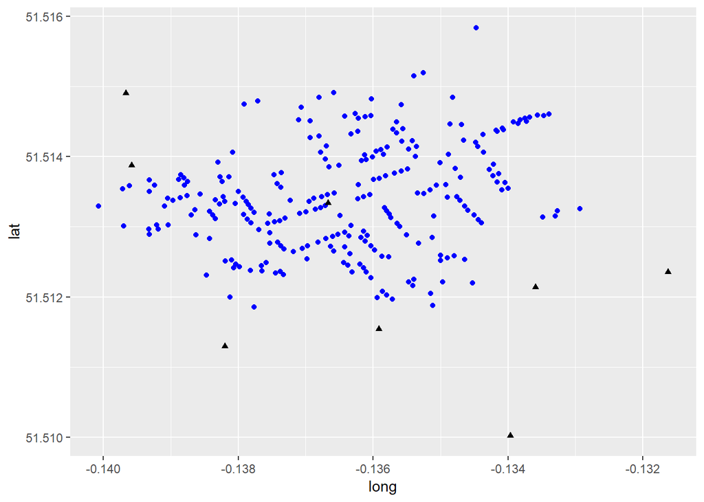

```r
ggplot() +
  geom_point(data = snow_deaths, aes(x = long, y = lat), color = "blue", shape = 16) +
  geom_point(data = snow_pumps, aes(x = long, y = lat), color = "black", shape = 17)
```

This does a decent job of displaying the information, now using different colors and shapes for different types of events (deaths and pumps). However, it is not a very good quality map.

A package that extends the functionality of mapping in R is `leaflet`. We will see next how to enhance our proportional symbol map using this package. First you need to load the package (you need to install it first if you have not already):

```r
library(leaflet)
```

The first step is to create a `leaflet` object, which will be saved in `m`. To do this we use the function `leaflet` and we indicate a dataset to use for our map, in this case the dataframe `snow_deaths`. In addition, we set the view for the map using the `setView` function, and indicate the center of the map (which we can get after inspecting the previous symbols map), as well as the zoom (16 is the zoom for a neighborhood):

```r
m <- leaflet(data = snow_deaths) %>% setView(lng = -0.136, lat = 51.513, zoom = 16)
```

We can add a basemap or background map by means of the `addTiles` function:

```r
m <- m %>% addTiles()
```

Finally, we add the cases of cholera deaths to the map. For this, we indicate the coordinates (preceded by `~`), and set an option for clustering by means of the `clusterOptions` as follows:

```r
m <- m %>% addMarkers(~long, ~lat, clusterOptions = markerClusterOptions(), group = "Deaths")
m
```

[interactive chart not shown]

To the map above we could also add the location of the pumps (notice that the Broad Street Pump is already shown in the basemap!):

```r
m %>% addMarkers(data = snow_pumps, ~long, ~lat, group = "Pumps")
```

[interactive chart not shown]

The above results in a much nicer map. Is this map informative? What does it tell you about the incidence of cholera and the location of the pumps?

We could even begin to do some spatial analysis on this map! For instance, we could create a *heatmap*. You have probably seen heatmaps in many different situations before, as they are a popular visualization tool. Heatmaps are created based on a spatial analytical technique called *kernel analysis*. We will cover this technique in more detail later on. For the time being, it can be illustrated by taking advantage of the `leaflet.extras` package, which contains a heatmap function. Load the package as follows:

```r
library(leaflet.extras)
```

Next, create a second leaflet object for this example, and call it `m2`. Notice that we are using the same `setView` parameters:

```r
m2 <- leaflet(data = snow_deaths) %>% setView(lng = -0.136, lat = 51.513, zoom = 16) %>% addTiles()
```

Then, add the heatmap. The function used to do this is `addHeatmap`. We specify the coordinates and the variable for the intensity (i.e., each case in the dataframe is representative of `Count` deaths at the address). Two parameters are important here, the `blur` and the `radius`. If you are working with the R notebook version of the book, experiment changing these parameters:

```r
m2 %>% addHeatmap(lng = ~long, lat = ~lat, intensity = ~Count,
             blur = 40, max = 1, radius = 25)
```

[interactive chart not shown]

Lastly, you can also add markers for the pumps as follows:

```r
m2 %>% addHeatmap(lng = ~long, lat = ~lat, intensity = ~Count,
             blur = 40, max = 1, radius = 25) %>%
  addMarkers(data = snow_pumps, ~long, ~lat, group = "Pumps")
```

[interactive chart not shown]

A heatmap (essentially a kernel density of spatial points; more on this in a later chapter) makes it very clear that most cases of cholera happend in the neighborhood of one (possibly contaminated) water pump! At the time, Snow noted with respect to this geographical pattern that:

“It will be observed that the deaths either very much diminished, or ceased altogether, at every point where it becomes decidedly nearer to send to another pump than to the one in Broad street. It may also be noticed that the deaths are most numerous near to the pump where the water could be more readily obtained.”

Snow’s analysis led to the closure of the pump, after which the cholera outbreak subsided. This illustrates how even some relatively simple spatial analysis can help to inform public policy and even save lives. You can read more about this case [here](https://en.wikipedia.org/wiki/1854_Broad_Street_cholera_outbreak).

In this practice you have learned how to implement some simple mapping and spatial statistical analysis using R. In future readings we will further explore the potential of R for both.

## Other resources

If you would like to experiment some more with this dataset, visit a Shiny app that lets you explore this dataset.

For more information on the functionality of `leaflet`, please check [Leaflet for R](https://rstudio.github.io/leaflet/)

## References

Wickham, Hadley. 2015. *R Packages: Organize, Test, Document, and Share Your Code*. “ O’Reilly Media, Inc.”